# Projekt

PValue

Significance

(Intercept)

(Intercept)

0.2015827

0.2143803

0.9403043

0.3470615

Age

Age

-0.1209771

0.0053775

-22.4971065

0.0000000

CGPA

CGPA

0.0728631

0.0149260

4.8816140

0.0000011

Work.Study.Hours

Work.Study.Hours

0.1109021

0.0059909

18.5118079

0.0000000

Academic.Pressure_1

Academic.Pressure_1

-3.4892078

0.0811618

-42.9907901

0.0000000

Academic.Pressure_2

Academic.Pressure_2

-2.3812451

0.0767933

-31.0084886

0.0000000

Academic.Pressure_3

Academic.Pressure_3

-1.5114902

0.0677511

-22.3094397

0.0000000

Academic.Pressure_4

Academic.Pressure_4

-0.7070286

0.0747105

-9.4635812

0.0000000

Study.Satisfaction_1

Study.Satisfaction_1

0.9851792

0.0755652

13.0374734

0.0000000

Study.Satisfaction_2

Study.Satisfaction_2

0.6081613

0.0728838

8.3442550

0.0000000

Study.Satisfaction_3

Study.Satisfaction_3

0.5024164

0.0717391

7.0033807

0.0000000

Study.Satisfaction_4

Study.Satisfaction_4

0.1694347

0.0698133

2.4269674

0.0152256

Sleep.Duration_2

Sleep.Duration_2

-0.3469912

0.0616252

-5.6306663

0.0000000

Sleep.Duration_3

Sleep.Duration_3

-0.3617249

0.0591570

-6.1146622

0.0000000

Sleep.Duration_4

Sleep.Duration_4

-0.5489941

0.0622944

-8.8128976

0.0000000

Dietary.Habits_2

Dietary.Habits_2

0.5286375

0.0544111

9.7156104

0.0000000

Dietary.Habits_3

Dietary.Habits_3

1.1277208

0.0555892

20.2866818

0.0000000

Have.you.ever.had.suicidal.thoughts.._Yes

Have.you.ever.had.suicidal.thoughts.._Yes

2.5319499

0.0474050

53.4110495

0.0000000

Financial.Stress_2

Financial.Stress_2

0.4060288

0.0696002

5.8337334

0.0000000

Financial.Stress_3

Financial.Stress_3

1.0864793

0.0697004

15.5878571

0.0000000

Financial.Stress_4

Financial.Stress_4

1.5982016

0.0695188

22.9894960

0.0000000

Financial.Stress_5

Financial.Stress_5

2.2837327

0.0724473

31.5226692

0.0000000

Family.History.of.Mental.Illness_Yes

Family.History.of.Mental.Illness_Yes

0.2887091

0.0439051

6.5757484

0.0000000

Career_Path_2

Career_Path_2

0.2441478

0.1085937

2.2482698

0.0245590

Career_Path_5

Career_Path_5

-0.2097637

0.0577813

-3.6303041

0.0002831

Testowanie progów odcięcia regresji logistycznej:

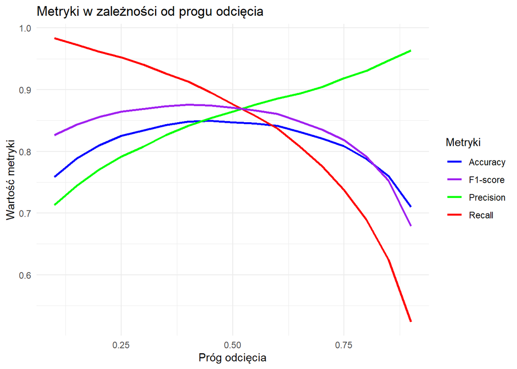

```r
evaluate_thresholds <- function(model, data, actual_col, thresholds) {
  # Rzeczywiste etykiety
  actual <- data[[actual_col]]

  # Predykcja prawdopodobieństw
  predicted_prob <- predict(model, data, type = "response")

  # Inicjalizacja wyników
  results <- data.frame(
    Threshold = numeric(),
    Accuracy = numeric(),
    Precision = numeric(),
    Recall = numeric(),
    F1 = numeric(),
    stringsAsFactors = FALSE
  )

  # Testowanie każdego progu
  for (threshold in thresholds) {
    # Predykcja klas na podstawie progu
    predicted_class <- ifelse(predicted_prob >= threshold, 1, 0)

    # Macierz pomyłek
    conf_matrix <- table(Predicted = predicted_class, Actual = actual)

    # Obliczanie metryk
    true_positive <- conf_matrix[2, 2]
    false_positive <- conf_matrix[2, 1]
    true_negative <- conf_matrix[1, 1]
    false_negative <- conf_matrix[1, 2]

    accuracy <- (true_positive + true_negative) / sum(conf_matrix)
    precision <- ifelse((true_positive + false_positive) > 0,
                        true_positive / (true_positive + false_positive),
                        0)
    recall <- ifelse((true_positive + false_negative) > 0,
                     true_positive / (true_positive + false_negative),
                     0)
    f1 <- ifelse((precision + recall) > 0,
                 2 * (precision * recall) / (precision + recall),
                 0)

    # Dodanie wyników do ramki danych
    results <- rbind(results, data.frame(
      Threshold = threshold,
      Accuracy = accuracy,
      Precision = precision,
      Recall = recall,
      F1 = f1
    ))
  }

  return(results)
}

# Testowanie progów odcięcia
thresholds <- seq(0.1, 0.9, by = 0.05)  # Zakres progów od 0.1 do 0.9
results <- evaluate_thresholds(final_model, test_data_encoded, "Depression_1", thresholds)

# Wizualizacja wyników
library(ggplot2)
ggplot(results, aes(x = Threshold)) +
  geom_line(aes(y = Accuracy, color = "Accuracy"), linewidth = 1) +
  geom_line(aes(y = Precision, color = "Precision"), linewidth = 1) +
  geom_line(aes(y = Recall, color = "Recall"), linewidth = 1) +
  geom_line(aes(y = F1, color = "F1-score"), linewidth = 1) +
  labs(title = "Metryki w zależności od progu odcięcia",
       x = "Próg odcięcia",
       y = "Wartość metryki") +
  scale_color_manual(values = c("Accuracy" = "blue",
                                "Precision" = "green",
                                "Recall" = "red",
                                "F1-score" = "purple"),
                     name = "Metryki") +
  theme_minimal()
```

Najlepszy próg odcięcia:

```r
# Znalezienie najlepszego progu na podstawie F1-score
best_threshold <- results[which.max(results$F1), ]
 best_threshold$Threshold
```

```
## [1] 0.4
```

Metryki dla najlepszego progu:

```r
data.frame(best_threshold)
```

|  | Threshold | Accuracy | Precision | Recall | F1 |
| --- | --- | --- | --- | --- | --- |
| 7 | 0.4 | 0.8483503 | 0.8414588 | 0.9128741 | 0.8757129 |

Najlepszy próg został wybrany na podstawie wartości metryki F1-score. Pozwala ona zachować balans między precyzją i czułością.

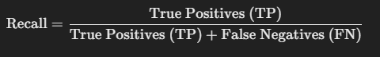

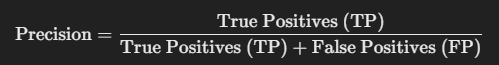

Wyniki regresji logistycznej:

Zbiór uczący - macierz pomyłek:

```r
predicted_probabilities <- predict(final_model, newdata = train_data_encoded, type = "response")
predicted_classes <- ifelse(predicted_probabilities > 0.4, 1, 0)
confusion_matrix <- table(train_data_encoded$Depression_1, predicted_classes)
print(confusion_matrix)
```

```
##    predicted_classes
##         0     1
##   0  5957  2112
##   1   892 10492
```

```r
accuracy1 <- sum(diag(confusion_matrix)) / sum(confusion_matrix)
print(paste0("Dokładność na zbiorze uczacym: ", accuracy1))
```

```
## [1] "Dokładność na zbiorze uczacym: 0.845576517760757"
```

Dokładność na zbiorze uczącym nie wskazuje na przeuczenie modelu.

```r
# Regresja logistyczna na zbiorze testowym
predicted_probabilities_test <- predict(final_model, newdata = test_data_encoded, type = "response")
predicted_classes_test <- ifelse(predicted_probabilities_test > 0.4, 1, 0)
predicted_probabilities <- predicted_probabilities_test
predicted_classes <- predicted_classes_test
confusion_matrix_test <- table(test_data_encoded$Depression_1, predicted_classes)
print(confusion_matrix_test)
```

```
##    predicted_classes
##        0    1
##   0 2618  839
##   1  425 4453
```

```r
#accuracy2 <- sum(diag(confusion_matrix_test)) / sum(confusion_matrix_test)
#print(paste0("Dokładność na zbiorze testowym: ", accuracy2))
```

## KNN

Algorytm KNN działa w uproszczeniu w 3 krokach:

1. Oblicza odległości między nowym punktem a wszystkimi punktami w zbiorze treningowym

2. Znajduje k (w tym przypadku 3) najbliższych sąsiadów

3. Klasyfikuje punkt na podstawie wiekszosci głosów spośród tych sąsiadów

```r
columns_to_scale <- c("CGPA", "Work.Study.Hours", "Age")
train_data_encoded_scale <- train_data_encoded
test_data_encoded_scale <- test_data_encoded
# Standaryzacja kolumn numerycznych w zbiorze treningowym
train_data_encoded_scale[, columns_to_scale] <- scale(train_data_encoded[, columns_to_scale])

# Standaryzacja kolumn numerycznych w zbiorze testowym
test_data_encoded_scale[, columns_to_scale] <- scale(test_data_encoded[, columns_to_scale])
library(class)

# Definiowanie cech (bez zmiennej celu)
features <- colnames(train_data_encoded_scale)[-which(colnames(train_data_encoded_scale) == "Depression_1")]

# Algorytm KNN - Predykcja na zbiorze uczącym
knn_train <- knn(
  train = train_data_encoded_scale[, features],  # Cechy zbioru treningowego
  test = train_data_encoded_scale[, features],  # Cechy zbioru treningowego
  cl = train_data_encoded_scale$Depression_1,   # Klasy w zbiorze treningowym
  k = 3,
  prob = TRUE
)


# Wyniki dla zbioru uczącego
cat("Macierz pomyłek dla zbioru uczącego:\n")
```

```
## Macierz pomyłek dla zbioru uczącego:
```

```r
print(table(knn_train, train_data_encoded_scale$Depression_1))
```

```
##
## knn_train     0     1
##         0  6679   899
##         1  1390 10485
```

```r
cat("Dokładność - zbiór uczący:",
    sum(diag(table(knn_train, train_data_encoded_scale$Depression_1))) /
    sum(table(knn_train, train_data_encoded_scale$Depression_1)), "\n")
```

```
## Dokładność - zbiór uczący: 0.8823318
```

```r
knn_test <- knn(
  train = train_data_encoded_scale[, features],  # Cechy zbioru treningowego
  test = test_data_encoded_scale[, features],   # Cechy zbioru testowego
  cl = train_data_encoded_scale$Depression_1,   # Klasy w zbiorze treningowym
  k = 3                                         # Liczba sąsiadów
)

# Wyniki dla zbioru testowego
cat("\nMacierz pomyłek dla zbioru testowego:\n")
```

```
##
## Macierz pomyłek dla zbioru testowego:
```

```r
print(table(knn_test, test_data_encoded_scale$Depression_1))
```

```
##
## knn_test    0    1
##        0 2458  776
##        1  999 4102
```

```r
cat("Dokładność - zbiór testowy:",
    sum(diag(table(knn_test, test_data_encoded_scale$Depression_1))) /
    sum(table(knn_test, test_data_encoded_scale$Depression_1)), "\n")
```

```
## Dokładność - zbiór testowy: 0.7870426
```

Model osiąga wyższą dokładność na zbiorze treningowym o około 10 punktów procentowych, co świadczy o delikatnym przetrenowaniu modelu.

# Analiza uzyskanych wyników

## Krzywa ROC

Krzywa ROC (Receiver Operating Characteristic) przedstawia zależność między współczynnikiem prawdziwie pozytywnych wyników (True Positive Rate, TPR) a współczynnikiem fałszywie pozytywnych wyników (False Positive Rate, FPR) przy różnych progach decyzji.

**AUC** (Area Under the Curve) to pole pod krzywą ROC i stanowi miarę ogólnej skuteczności modelu. Wartość AUC mieści się w przedziale od 0 do 1:

- **AUC = 1** oznacza idealny model, który zawsze poprawnie klasyfikuje wszystkie przypadki.
- **AUC = 0,5** oznacza model losowy, który nie jest lepszy od zgadywania.
- **AUC < 0,5** oznacza bardzo zły model, który częściej popełnia błędy niż trafnie klasyfikuje.

Im wyższa wartość AUC, tym lepiej model radzi sobie z rozróżnianiem między klasami pozytywnymi a negatywnymi.

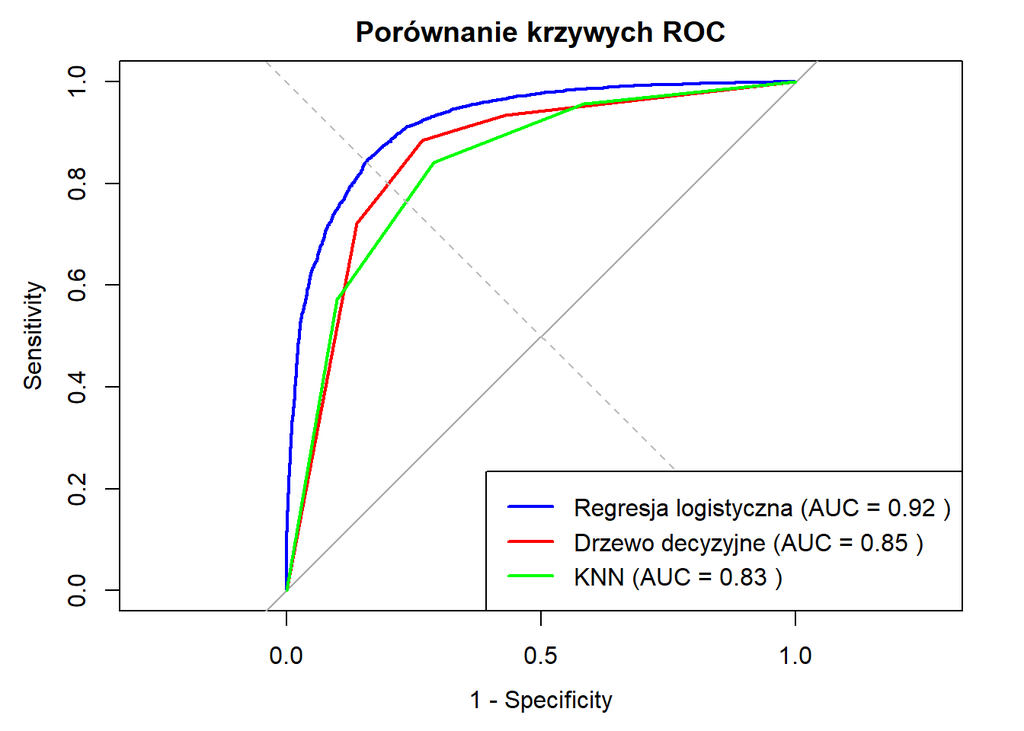

```r
# Ładowanie biblioteki
library(pROC)

# Predykcje prawdopodobieństw z modelu regresji logistycznej
logistic_predicted_prob <- predict(final_model, test_data_encoded, type = "response")

# Predykcje prawdopodobieństw z najlepszego drzewa decyzyjnego
tree_predicted_prob <- predict(best_model, test_data, type = "prob")[, 2]  # Prawdopodobieństwo klasy "1"

# Rzeczywiste etykiety (zmienna celu)
true_labels1 <- as.factor(test_data_encoded$Depression_1)
true_labels2 <- as.factor(test_data$Depression)

# Krzywa ROC dla regresji logistycznej
roc_logistic <- roc(true_labels1, logistic_predicted_prob)
auc_logistic <- auc(roc_logistic)

# Krzywa ROC dla drzewa decyzyjnego
roc_tree <- roc(true_labels2, tree_predicted_prob)
auc_tree <- auc(roc_tree)

# Algorytm KNN z przewidywaniem prawdopodobieństw
knn_test_prob <- knn(
  train = train_data_encoded_scale[, features],  # Cechy zbioru treningowego
  test = test_data_encoded_scale[, features],   # Cechy zbioru testowego
  cl = train_data_encoded_scale$Depression_1,     # Klasy w zbiorze treningowym
  k = 3,                                        # Liczba sąsiadów
  prob = TRUE                                   # Zwracanie prawdopodobieństw
)

# Uzyskiwanie prawdopodobieństw dla klasy "1"
probabilities_knn <- attr(knn_test_prob, "prob")
# Korygowanie prawdopodobieństw: musimy uwzględnić, że zwracane są dla przewidywanej klasy
probabilities_knn <- ifelse(knn_test_prob == "1", probabilities_knn, 1 - probabilities_knn)

# Rzeczywiste etykiety (zmienna celu)
true_labels3 <- as.factor(test_data_encoded$Depression_1)

# Krzywa ROC dla KNN
roc_knn <- roc(true_labels3, probabilities_knn)
auc_knn <- auc(roc_knn)

# Dodanie KNN do wykresu ROC
plot(roc_logistic, col = "blue", main = "Porównanie krzywych ROC", legacy.axes = TRUE, lwd = 2)
lines(roc_tree, col = "red", lwd = 2)
lines(roc_knn, col = "green", lwd = 2)

# Dodanie linii dla klasyfikatora losowego
abline(a = 0, b = 1, col = "gray", lty = 2)

# Dodanie legendy
legend("bottomright",
       legend = c(paste("Regresja logistyczna (AUC =", round(auc_logistic, 2), ")"),
                  paste("Drzewo decyzyjne (AUC =", round(auc_tree, 2), ")"),
                  paste("KNN (AUC =", round(auc_knn, 2), ")")),
       col = c("blue", "red", "green"),
       lwd = 2)
```

Przekątna na wykresie (linia szara nieprzerywana) reprezentuje model losowy, który nie jest lepszy od zgadywania. Model znajdujący się blisko tej linii ma niską skuteczność. Im bardziej krzywa zbliża się do lewego górnego rogu wykresu, tym lepsza jest jakość klasyfikacji modelu.

```r
# Funkcja obliczająca metryki klasyfikacji
calculate_metrics <- function(confusion_matrix) {
  TP <- confusion_matrix[2, 2] # True Positives
  TN <- confusion_matrix[1, 1] # True Negatives
  FP <- confusion_matrix[1, 2] # False Positives
  FN <- confusion_matrix[2, 1] # False Negatives

  # Obliczenia
  accuracy <- (TP + TN) / sum(confusion_matrix)
  precision <- ifelse((TP + FP) > 0, TP / (TP + FP), 0)
  recall <- ifelse((TP + FN) > 0, TP / (TP + FN), 0)
  f1_score <- ifelse((precision + recall) > 0, 2 * (precision * recall) / (precision + recall), 0)

  return(c(Accuracy = accuracy, Precision = precision, Recall = recall, F1_Score = f1_score))
}

# Funkcja do obliczania i przechowywania wyników
get_metrics_table <- function(model_name, pred_train, pred_test, train_data, test_data) {
  # Macierze pomyłek
  conf_matrix_train <- table(Actual = train_data$Depression, Predicted = pred_train)
  conf_matrix_test <- table(Actual = test_data$Depression, Predicted = pred_test)

  # Metryki
  train_metrics <- calculate_metrics(conf_matrix_train)
  test_metrics <- calculate_metrics(conf_matrix_test)

  # Tworzenie tabeli wyników
  results <- data.frame(
    Model = model_name,
    Dataset = c("Train", "Test"),
    Accuracy = c(train_metrics["Accuracy"], test_metrics["Accuracy"]),
    Precision = c(train_metrics["Precision"], test_metrics["Precision"]),
    Recall = c(train_metrics["Recall"], test_metrics["Recall"]),
    F1_Score = c(train_metrics["F1_Score"], test_metrics["F1_Score"])
  )

  return(results)
}

# Obliczenia dla regresji logistycznej
logistic_pred_train <- predict(final_model, train_data_encoded, type = "response") > 0.5
logistic_pred_test <- predict(final_model, test_data_encoded, type = "response") > 0.5
logistic_metrics <- get_metrics_table("Logistic Regression", logistic_pred_train, logistic_pred_test, train_data_encoded, test_data_encoded)

# Obliczenia dla drzewa decyzyjnego
tree_pred_train <- predict(best_model, train_data, type = "class")
tree_pred_test <- predict(best_model, test_data, type = "class")
tree_metrics <- get_metrics_table("Decision Tree", tree_pred_train, tree_pred_test, train_data, test_data)

knn_metrics <- get_metrics_table("KNN", knn_train, knn_test, train_data_encoded_scale, test_data_encoded_scale)

# Połączenie wyników w jedną tabelę
final_results <- rbind(logistic_metrics, tree_metrics, knn_metrics)

# Wyświetlenie wyników
data.frame(final_results)
```

| Model | Dataset | Accuracy | Precision | Recall | F1_Score |
| --- | --- | --- | --- | --- | --- |
| Logistic Regression | Train | 0.8479412 | 0.8573974 | 0.8878250 | 0.8723459 |
| Logistic Regression | Test | 0.8472705 | 0.8643622 | 0.8765888 | 0.8704326 |
| Decision Tree | Train | 0.8219298 | 0.8171044 | 0.8963457 | 0.8548928 |
| Decision Tree | Test | 0.8219556 | 0.8242262 | 0.8843788 | 0.8532437 |
| KNN | Train | 0.8823318 | 0.8829474 | 0.9210295 | 0.9015865 |
| KNN | Test | 0.7870426 | 0.8041560 | 0.8409184 | 0.8221265 |

1. **Logistic Regression**:
   - Spójne wyniki między danymi treningowymi i testowymi oraz wysoka dokładność (~0.85)
   - Wysoka precyzja (~0.86) i recall (~0.88), co prowadzi do dobrego balansu (F1-Score ~0.87).
2. **Decision Tree**:
   - Wyniki dla danych testowych są zbliżone do treningowych, co sugeruje brak dużego przeuczenia.
   - Metryki są nieco niższe niż w przypadku Logistic Regression, ale model osiąga dobrą dokładność na zbiorze testowym (~0.82)
3. **KNN**:
   - Najwyższe wyniki na danych treningowych, ale znacząco spadają na danych testowych. Wskazuje to na przeuczenie modelu.

### Wnioski:

- **Logistic Regression** wydaje się najbardziej stabilnym modelem o dobrym zbalansowaniu metryk.

# Analiza interpetowalności

## Wykresy częściowej zależności (Partial Dependance Plots)

```r
library(pdp)
library(ggplot2)
library(gridExtra)
library(htmltools)
# Lista zmiennych do usunięcia
variables_to_remove <- c(
  "Gender_Male",
  "Career_Path_1",
  "Career_Path_3",
  "Degree_Level_3",
  "Career_Path_4",
  "Degree_Level_1",
  "Degree_Level_2",
  "Academic.Pressure_5",
  "Study.Satisfaction_5"
)

# Usunięcie zmiennych ze zbioru danych
cleaned_data <- train_data_encoded[, !(names(train_data_encoded) %in% variables_to_remove)]

# Lista zmiennych użytych w modelu
variables <- colnames(cleaned_data)[-which(names(cleaned_data) == "Depression_1")]

# Tworzenie listy na wykresy
pdp_plots <- list()

# Generowanie PDP dla każdej zmiennej
for (var in variables) {
  cat("Generowanie PDP dla zmiennej:", var, "\n")

  # Obliczenie PDP z prawdopodobieństwem dla klasy 1
  pdp <- partial(
    object = final_model,
    pred.var = var,
    train = train_data_encoded,
    prob = TRUE,  # Wyliczanie prawdopodobieństw
    which.class = 2  # Zakładamy, że klasa "1" jest drugą w poziomach
  )

  # Tworzenie wykresu PDP
  pdp_plot <- autoplot(pdp) +
    ggtitle(paste(var)) +
    xlab(var) +
    ylab("Prawdopodobieństwo klasy 1") +
    theme_minimal(base_size = 10) +
    theme(
      plot.title = element_text(size = 6),
      axis.title = element_text(size = 6),
      axis.text = element_text(size = 6)
    )

  # Dodanie wykresu do listy
  pdp_plots[[var]] <- pdp_plot
}
```

```
## Generowanie PDP dla zmiennej: Age
## Generowanie PDP dla zmiennej: CGPA
## Generowanie PDP dla zmiennej: Work.Study.Hours
## Generowanie PDP dla zmiennej: Academic.Pressure_1
```

```
## Generowanie PDP dla zmiennej: Academic.Pressure_2
```

```
## Generowanie PDP dla zmiennej: Academic.Pressure_3
```

```
## Generowanie PDP dla zmiennej: Academic.Pressure_4
```

```
## Generowanie PDP dla zmiennej: Study.Satisfaction_1
```

```
## Generowanie PDP dla zmiennej: Study.Satisfaction_2
```

```
## Generowanie PDP dla zmiennej: Study.Satisfaction_3
```

```
## Generowanie PDP dla zmiennej: Study.Satisfaction_4
```

```
## Generowanie PDP dla zmiennej: Sleep.Duration_2
## Generowanie PDP dla zmiennej: Sleep.Duration_3
## Generowanie PDP dla zmiennej: Sleep.Duration_4
## Generowanie PDP dla zmiennej: Dietary.Habits_2
## Generowanie PDP dla zmiennej: Dietary.Habits_3
## Generowanie PDP dla zmiennej: Have.you.ever.had.suicidal.thoughts.._Yes
## Generowanie PDP dla zmiennej: Financial.Stress_2
## Generowanie PDP dla zmiennej: Financial.Stress_3
## Generowanie PDP dla zmiennej: Financial.Stress_4
## Generowanie PDP dla zmiennej: Financial.Stress_5
## Generowanie PDP dla zmiennej: Family.History.of.Mental.Illness_Yes
## Generowanie PDP dla zmiennej: Career_Path_2
## Generowanie PDP dla zmiennej: Career_Path_5
```

```
## Renderowanie grupy wykresów: 1
```

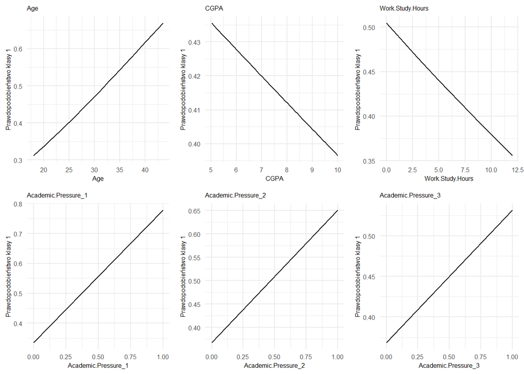

```
## Renderowanie grupy wykresów: 2
```

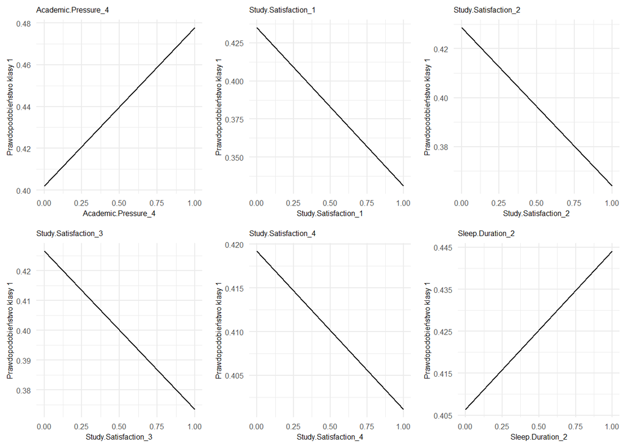

```
## Renderowanie grupy wykresów: 3
```

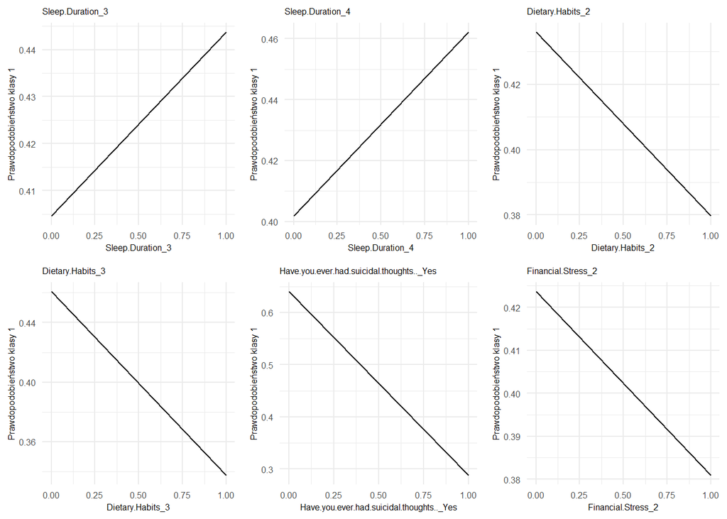

```
## Renderowanie grupy wykresów: 4
```

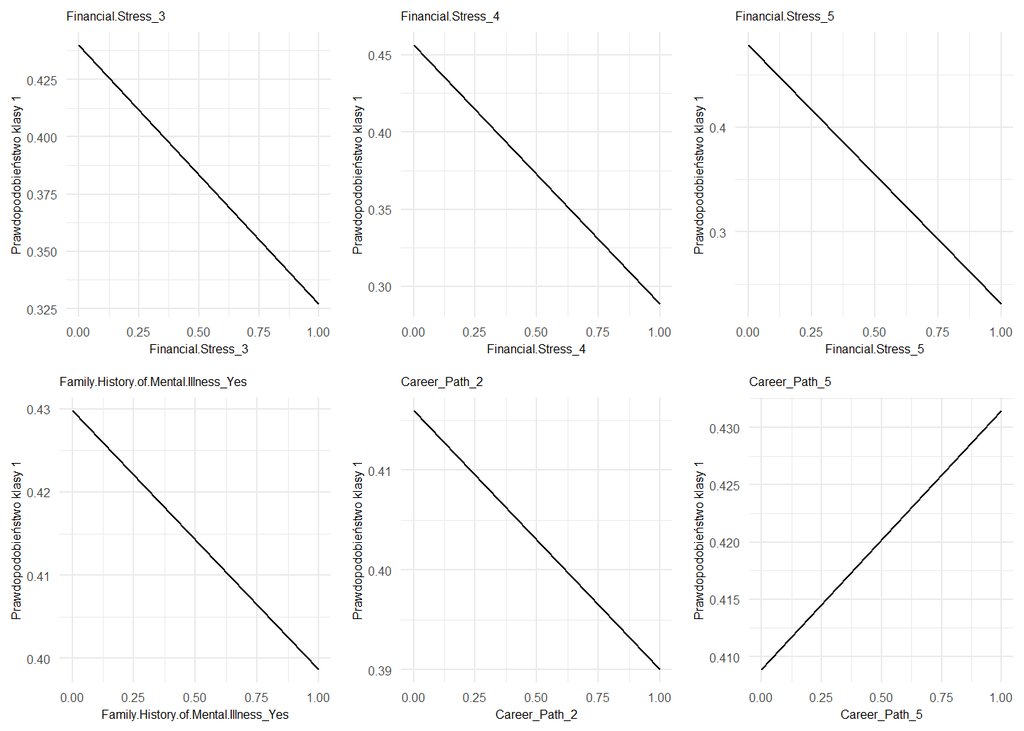

```r
split_plots <- function(plots, ncol) {
  split(plots, ceiling(seq_along(plots) / ncol))
}

grouped_plots <- split_plots(pdp_plots, 6)

for (i in seq_along(grouped_plots)) {
  cat("Renderowanie grupy wykresów:", i, "\n")
  grid.arrange(grobs = grouped_plots[[i]], ncol = 3)  # 2 kolumny w siatce
}
```

### Analiza:

# Podsumowanie i wnioski

W badaniu przeanalizowaliśmy trzy rodzaje modeli uczenia maszynowego:

1. Drzewo decyzyjne (z wykorzystaniem baggingu)
2. Regresja logistyczna
3. KNN

Spośród nich najlepszym okazał się model regresji logistycznej.

Zmienne o największym wpływie (największe współczynniki lub ich wartości bezwzględne):